# Conversation Design and Belief Change

Casey McMahon

2026-05-06

# Belief Change in Structured Conversations

*This study was conducted in collaboration with Dr. Alin Coman and Dr. William Thompson*

This project analyzes data from a structured online conversation study in which participants discussed climate change in four-person chat rooms. Participants were grouped by their starting beliefs so that conversations varied in composition: mostly believers, balanced groups, or mostly skeptics.

The broader people science question is not only whether conversation changes minds, but **for whom**, **under what social conditions**, and whether belief change translates into behavioral intention.

## Analysis plan

1. Build reliable pre/post belief and behavioral intention scales.
2. Calculate belief change as post-conversation belief minus pre-conversation belief.
3. Test whether belief change differs by starting belief and conversation composition.
4. Analyze behavioral intention separately from belief change.
5. Treat message/paragraph choice as exploratory unless it clearly supports the main story.

## Study design

Conversation group composition

| Conversation type | Believers | Skeptics | Interpretation |
| --- | --- | --- | --- |
| Mostly believers | 3 | 1 | Skeptic is in the minority |
| Balanced | 2 | 2 | Equal exposure |
| Mostly skeptics | 1 | 3 | Believer is in the minority |

## Analyses

### Measurement reliability

Our scales have acceptable reliablity (alpha > .80)

Scale reliability

| Scale | Alpha |
| --- | --- |
| Climate belief scale, pre-conversation | 0.81 |
| Climate belief scale, post-conversation | 0.85 |
| Behavioral intention scale | 0.81 |

### 1. Belief change

#### Model + Visualization

Note: Belief change is calculated as post-conversation climate belief minus pre-conversation climate belief. Higher values indicate stronger climate belief after the conversation relative to baseline.

**Show full model details**

Mixed-effects model predicting belief change

| Predictor | b | SE | t | p |  |
| --- | --- | --- | --- | --- | --- |
| Skeptic participant | 6.24 | 3.48 | 1.79 | 0.075 | † |
| Balanced conversation group | -1.67 | 3.87 | -0.43 | 0.667 |  |
| Mostly skeptic conversation group | -7.19 | 4.42 | -1.63 | 0.106 |  |
| Skeptic participant × Balanced group | 0.43 | 4.60 | 0.09 | 0.925 |  |
| Skeptic participant × Mostly skeptic group | 4.92 | 4.92 | 1.00 | 0.319 |  |

Note. Reference group: believers in mostly-believer conversation groups. Estimates are fixed effects from a linear mixed-effects model with chat room included as a random intercept. † = p < .10, * = p < .05, ** = p < .01, *** = p < .001.

**Post-hoc tests**

1. Did each group differ from 0 (i.e., no belief change)?

Estimated belief change relative to no change

| Starting belief | Conversation composition | Estimated change | SE | df | t | p |  |
| --- | --- | --- | --- | --- | --- | --- | --- |
| Believer | Mostly believers | -5.85 | 2.59 | 56.8 | -2.25 | 0.157 |  |
| Skeptic | Mostly believers | 0.40 | 3.58 | 145.7 | 0.11 | 1.000 |  |
| Believer | Balanced | -7.52 | 2.87 | 81.9 | -2.62 | 0.061 | † |
| Skeptic | Balanced | -0.84 | 2.87 | 81.9 | -0.29 | 1.000 |  |
| Believer | Mostly skeptics | -13.04 | 3.58 | 145.7 | -3.65 | 0.002 | ∗∗ |
| Skeptic | Mostly skeptics | -1.88 | 2.59 | 56.8 | -0.72 | 0.979 |  |

Note. Tests compare estimated belief change against zero. Positive values indicate stronger climate belief after the conversation; negative values indicate weaker climate belief after the conversation. p-values are Sidak-adjusted across the six tests. † = p < .10, ∗ = p < .05, ∗∗ = p < .01, ∗∗∗ = p < .001.

The tests against no change (i.e., change = 0) suggest that average belief movement was concentrated among believers, particularly when believers were in more mixed or skeptical conversation contexts. Believers in balanced groups showed marginal evidence of change from zero, while believers in mostly-skeptic groups showed clearer evidence of change. Skeptics, by contrast, did not show clear evidence of average belief movement across conversation compositions.

This distinction matters because the intervention did not appear to produce symmetric movement among believers and skeptics. Rather, the strongest evidence of movement emerged among participants who already accepted climate change when they were placed in conversations with more skeptical peers.

2. Relative to skeptics, do believers change their beliefs more across conversation type?

Believer–skeptic differences in belief change within each conversation composition

| Conversation composition | Contrast | Estimate | SE | df | t | p |  |
| --- | --- | --- | --- | --- | --- | --- | --- |
| Mostly believers | Believer − Skeptic | -6.24 | 3.48 | 141.0 | -1.79 | 0.075 | † |
| Balanced | Believer − Skeptic | -6.68 | 3.01 | 141.0 | -2.22 | 0.028 | ∗ |
| Mostly skeptics | Believer − Skeptic | -11.17 | 3.48 | 141.0 | -3.21 | 0.002 | ∗∗ |

Note. Negative estimates indicate that believers showed more negative belief change than skeptics within the same conversation composition. † p < .10, ∗ p < .05, ∗∗ p < .01, ∗∗∗ p < .001.

We see here that the believer/skeptic asymmetry was strongest in mostly-skeptic groups. Believers moved downward relative to skeptics, especially when they were exposed to more skeptical conversation partners.

Together, the follow-up tests suggest that belief movement was concentrated among participants who began as climate believers, not among skeptics. Importantly, this movement was negative: believers reported weaker climate beliefs after the conversation, particularly when they were in balanced or mostly-skeptic groups.

Pairwise comparisons within each conversation composition showed that believers changed their beliefs more towards skepticism (relative to skeptics). This difference was marginal in mostly-believer groups, statistically significant in balanced groups, and strongest in mostly-skeptic groups. Together, these results suggest that conversational exposure to skeptical peers did not symmetrically persuade both groups. Instead, the clearest movement occurred among already-convinced participants, whose beliefs weakened in more skeptical conversational contexts. The plot below visualizes these effects.

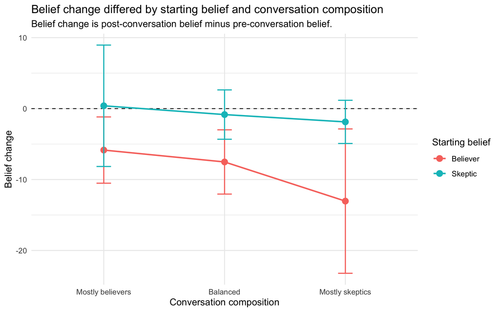

#### Takeaway

The belief-change results suggest that structured conversation did not move all participants equally. Participants who began as climate believers appeared more responsive to the conversation than participants who began as skeptics.

This matters for intervention design because conversation-based approaches are often treated as broadly persuasive. These results suggest that the same conversation format may have different effects depending on the audience segment and the social composition of the group.

**Additional movement change by participant analyses**

Below is a summary table of the number of participants who moved and in what direction

Direction of belief movement by starting belief and conversation composition

| Starting belief | Conversation composition | Movement direction | n | Percent |
| --- | --- | --- | --- | --- |
| Believer | Mostly believers | Moved toward stronger climate belief | 4 | 8.3% |
| Believer | Mostly believers | No meaningful change | 30 | 62.5% |
| Believer | Mostly believers | Moved toward weaker climate belief | 14 | 29.2% |
| Believer | Balanced | Moved toward stronger climate belief | 3 | 9.4% |
| Believer | Balanced | No meaningful change | 16 | 50% |
| Believer | Balanced | Moved toward weaker climate belief | 13 | 40.6% |
| Believer | Mostly skeptics | Moved toward stronger climate belief | 1 | 6.2% |
| Believer | Mostly skeptics | No meaningful change | 8 | 50% |
| Believer | Mostly skeptics | Moved toward weaker climate belief | 7 | 43.8% |
| Skeptic | Mostly believers | Moved toward stronger climate belief | 3 | 18.8% |
| Skeptic | Mostly believers | No meaningful change | 11 | 68.8% |
| Skeptic | Mostly believers | Moved toward weaker climate belief | 2 | 12.5% |
| Skeptic | Balanced | Moved toward stronger climate belief | 5 | 15.6% |
| Skeptic | Balanced | No meaningful change | 19 | 59.4% |
| Skeptic | Balanced | Moved toward weaker climate belief | 8 | 25% |
| Skeptic | Mostly skeptics | Moved toward stronger climate belief | 5 | 10.4% |
| Skeptic | Mostly skeptics | No meaningful change | 34 | 70.8% |
| Skeptic | Mostly skeptics | Moved toward weaker climate belief | 9 | 18.8% |

Note. Movement direction was classified using a threshold of 10 points on the 0–100 belief scale. Participants with belief change greater than or equal to the threshold were classified as moving toward stronger climate belief; participants with belief change less than or equal to the negative threshold were classified as moving toward weaker climate belief.

Plot the composition x belief

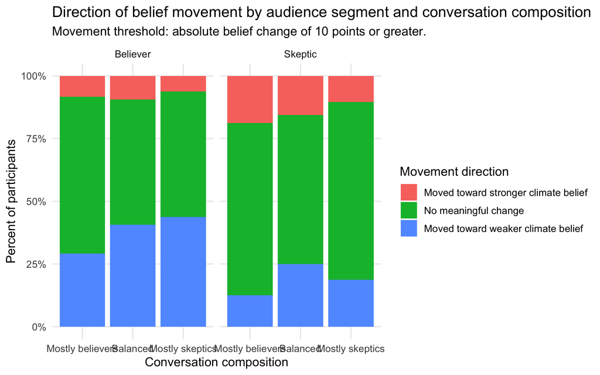

### 2. Opposing view exposure

#### Model + Visualization

This analysis reframes conversation composition as an exposure variable: the number of people in the group who started with the opposing belief. This is useful for translating the study design into a broader intervention-design concept.

**Show full model details**

Mixed-effects model predicting belief change based on opposing views

| Predictor | b | SE | t | p |  |
| --- | --- | --- | --- | --- | --- |
| Skeptic participant | -0.76 | 6.85 | -0.11 | 0.912 |  |
| Number of opposing-view partners | -3.32 | 2.15 | -1.55 | 0.125 |  |
| Skeptic participant × Opposing-view partners | 4.33 | 3.55 | 1.22 | 0.229 |  |

Note. Reference group: believers in mostly-believer conversation groups. Estimates are fixed effects from a linear mixed-effects model with chat room included as a random intercept. † = p < .10, * = p < .05, ** = p < .01, *** = p < .001.

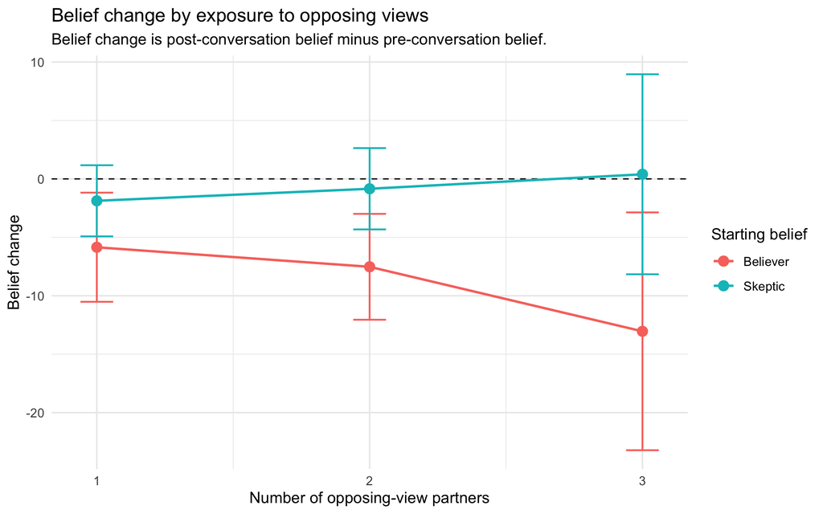

#### Takeaway

The opposing-view exposure analysis suggests that exposure to disagreement did not operate like a simple persuasive “dose.” As the number of opposing-view partners increased, believers showed increasingly negative average belief change, while skeptics remained close to no average change.

This pattern reinforces the asymmetry in the main analysis: conversation with opposing-view partners appeared to move already-convinced participants more than skeptics, and the direction of that movement was toward weaker climate belief among believers.

### 3. Behavioral intention

#### Model + Visualization

I analyzed behavioral intention separately from belief change because changing what people believe and changing what people intend to do are related but distinct intervention outcomes.

**Show full model details**

Mixed-effects model predicting behavioral intention

| Predictor | b | SE | t | p |  |
| --- | --- | --- | --- | --- | --- |
| Belief change | 0.04 | 0.01 | 3.93 | < .001 | ∗∗∗ |
| Skeptic participant | -0.65 | 0.35 | -1.85 | 0.066 | † |
| Balanced conversation group | -0.19 | 0.31 | -0.62 | 0.535 |  |
| Mostly skeptic conversation group | 0.20 | 0.40 | 0.50 | 0.616 |  |
| Belief change × Skeptic participant | -0.04 | 0.02 | -1.89 | 0.060 | † |
| Belief change × Balanced conversation group | -0.04 | 0.02 | -1.97 | 0.050 | † |
| Belief change × Mostly skeptic conversation group | -0.04 | 0.02 | -2.10 | 0.037 | ∗ |
| Skeptic participant × Balanced conversation group | -0.16 | 0.48 | -0.34 | 0.738 |  |
| Skeptic participant × Mostly skeptic conversation group | -0.46 | 0.53 | -0.87 | 0.388 |  |
| Belief change × Skeptic participant × Balanced conversation group | 0.06 | 0.03 | 1.78 | 0.077 | † |
| Belief change × Skeptic participant × Mostly skeptic conversation group | 0.06 | 0.03 | 2.12 | 0.035 | ∗ |

Note. Reference group: believers in mostly-believer conversation groups. Estimates are fixed effects from a linear mixed-effects model with chat room included as a random intercept. † = p < .10, ∗ = p < .05, ∗∗ = p < .01, ∗∗∗ = p < .001.

**Post-hoc tests**

1. Is belief change associated with behavioral intention differently for believers and skeptics?

Estimated association between belief change and behavioral intention by starting belief

| Starting belief | Belief-change slope | SE | Lower 95% CI | Upper 95% CI |
| --- | --- | --- | --- | --- |
| Believer | 0.02 | 0.01 | -0.00 | 0.03 |
| Skeptic | 0.02 | 0.01 | -0.00 | 0.04 |

2. Do skeptics and believers differ in behavioral intention within each conversation composition?

Believer–skeptic differences in behavioral intention within each conversation composition

| Conversation composition | Contrast | b | SE | df | t | p |  |
| --- | --- | --- | --- | --- | --- | --- | --- |
| Mostly believers | Believer − Skeptic | 0.48 | 0.35 | 140.4 | 1.34 | 0.182 |  |
| Balanced | Believer − Skeptic | 0.90 | 0.31 | 141.8 | 2.89 | 0.005 | ∗∗ |
| Mostly skeptics | Believer − Skeptic | 1.21 | 0.37 | 148.4 | 3.28 | 0.001 | ∗∗ |

Note. Reference group: believers in mostly-believer conversation groups. Estimates are fixed effects from a linear mixed-effects model with chat room included as a random intercept. † = p < .10, ∗ = p < .05, ∗∗ = p < .01, ∗∗∗ = p < .001.

#### Visualizing belief change and behavioral intention by starting belief (skeptic v. believer)

This first behavioral intention plot focuses on the relationship between individual belief change and reported behavioral intention.

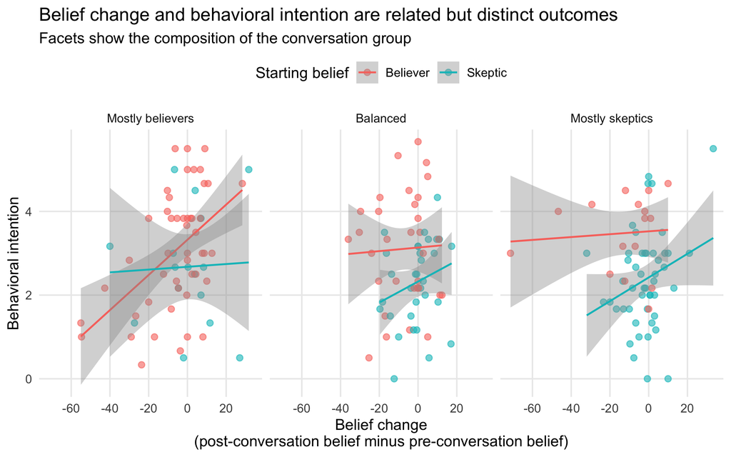

#### Behavioral intention by conversation composition and starting belief

This second plot shifts from that individual-level relationship to average behavioral intention by audience segment and conversation composition, making it easier to see whether believers and skeptics differed in reported willingness to act within the same conversation contexts.

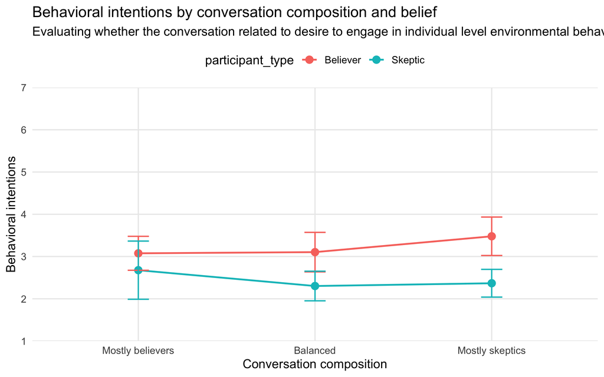

#### Takeaway

What we can see is that behavioral intention did not simply mirror belief change. Although believers showed negative belief movement in more skeptical conversation contexts, they still reported stronger behavioral intentions than skeptics, particularly in balanced and mostly-skeptic groups.

This suggests that belief strength and action-readiness should be treated as distinct intervention outcomes. A conversation may weaken stated belief certainty among already-concerned participants without reducing their willingness to act.

## Overall interpretation

Across analyses, the central finding is that structured conversation did not appear to move everyone equally. Participants’ starting beliefs mattered: believers appeared more movable than skeptics, and the effects of conversational context were not uniform across audience segments.

For intervention design, the broader implication is that dialogue-based approaches should be evaluated with attention to heterogeneity. Rather than asking only whether an intervention “works,” analysts should ask for whom it works, under what conditions, and whether attitudinal movement translates into behavioral intention.